# Matrix Completion

Fei Ding

2017/11/10

## Algorithm Description

**Algorithm preparation**:

define the SVThresholding function,the SVThresholding function is the singular value thresholding operator.  
For $A \in R^{m\times n}$,its condensed SVD is $A = U_r\Sigma_rV_r$,for constant $\lambda > 0$,the singular value thresholding operator is  
$SVThresholding(A) =U_r[\Sigma_r-\lambda I_r]_{+}V_r^T$,  
where $[\Sigma_r-\lambda I_r]_{+} = diag(\sigma_1-\lambda)_+,\dots,[\sigma_r-\lambda]_+)$.

Also define the the function of PCOmegaY,it is defined as follows:  
For any matrix $Y = (y_ij)\in R^{m\times n}$,the $PCOmegaY(Y) = (\tilde{y}_{ij})\in R^{m\times n}$ and  
$\tilde{y}= \begin{cases} 0 &(i,j)\in \Omega \\ y_{ij}\,&(i,j)\notin \Omega \end{cases}$  
where $\Omega$ is the subset of the the observed elements.

**Step0** Take $Y_1 = Z_0$,$Z_0$ is zeros matrix.,$t_1 = 1$

**Step k** $(k\geq 1)$ Compute  
$Z_k = SVThresholding(PCOmegaY(Y_k)+X)$  
$t_{k+1} = \frac{1+\sqrt{1+4t_k^2}}{2}$  
$Y_{k+1}=Z_k+(\frac{t_k-1}{t_{k+1}})(Z_k-Z_{k-1})$

**Loop until convergence**

## Complete the picture filling task

**library the package**

The task of matrix completion algorithm has been packed into R package named “dingfeiPG”.The first thing we have to do is to library the package.

```r
library("dingfeiPG")
```

**Read the Picture and Plot the Graph**

[figure not shown]

```r
# read in image and plot
library(jpeg)
img = readJPEG("./23.jpg")
img = img[,,1]
par(mar = c(0,0,0,0))
plot(0,0,type = "n")
rasterImage(img, -1, -1, 1, 1)
```

**Define the Set of Elements that are not Censored**

```r
# Define the set of elements that are not censored
#get the dim of the img matrix
m = dim(img)
n = dim(img)
#generate the Omega set
set.seed(100)
index = sample(c(1:length(img)),round(length(img)*0.4))
Omega = setdiff(1:length(img),index)
```

**Plot the Censored Plot Using the Omege Set**

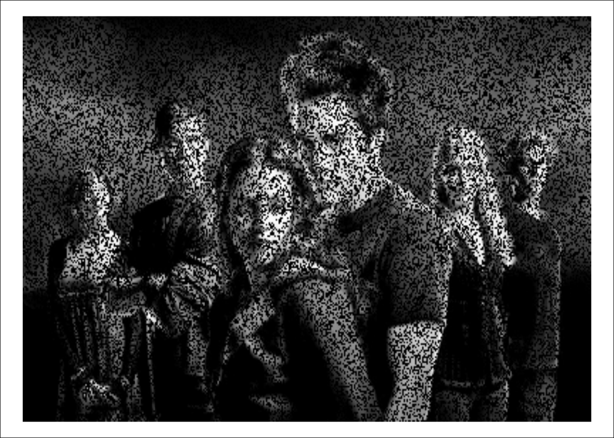

```r
#plot the censored plot using the Omege set
Pimg = img
Pimg[index] = 0
par(mar = c(0,0,0,0))
plot(0,0,type = "n")
rasterImage(Pimg, -1, -1, 1, 1)
```

**Using the Package to Fill the Picture**

[figure not shown]

```r
Pcomplete = dingfeiPG(Pimg,lambda = 0.23,Omega = Omega,index = index,maxinteration = 100)
par(mar = c(0,0,0,0))
plot(0,0,type = "n")
rasterImage(Pcomplete,-1,-1,1,1)
```